# Logistic Regression: Interactions

```r
library(tidyverse)
library(kableExtra)
```

Note: I’ve hidden the code here because the main goal is to illustrate what interactions are modeling, rather than the code for the model fitting process. You can click the “Show” button on the right in the sections you’re interested in.

# Data Simulation

Here I’m simulating some data to try to better explain interaction terms in logistic regression model. Let’s say we’re interested in modeling if somebody has a heart attack based on their biological sex and smoking status.

Let’s simulate 500 individuals to study:

```r
# setting seed so we always get the same numbers
set.seed(1234)

# Number of observations
n <- 500

# simulate predictors:
# sex (0 = male, 1 = female)
# smoking status (0 = non-smoker, 1 = smoker)
sex <- sample(0:1, n, replace = TRUE)
smoking <- sample(0:1, n, replace = TRUE)

# interaction (1 is female and smoker)
interaction <- sex * smoking


# outcome (probability of heart attacj)
log_odds <- -2.4 + -0.5 * sex + 1 * smoking - 0.2 * interaction
prob <- exp(log_odds)/(1+exp(log_odds))
outcome <- rbinom(n, 1, prob)

# save variables in a data frame
data <- data.frame(sex, smoking, interaction, outcome)
```

# Contingency Tables

Let’s now show the breakdown of people who did and did not have heart attacks based on sex and smoking.

```r
# contingency table
data %>%
  mutate(sex = ifelse(sex==0, "Male","Female"),
         smoking = ifelse(smoking==0, "Non-smoker","Smoker"))%>%
  group_by(sex, smoking) %>%
  summarise(event = sum(outcome), no_event = sum(1-outcome)) %>%
  mutate(total = event + no_event)
```

| sex | smoking | event | no_event | total |
| --- | --- | --- | --- | --- |
| Female | Non-smoker | 8 | 123 | 131 |
| Female | Smoker | 13 | 109 | 122 |
| Male | Non-smoker | 13 | 123 | 136 |
| Male | Smoker | 15 | 96 | 111 |

```r
# proportions
data %>%
  mutate(sex = ifelse(sex==0, "Male","Female"),
         smoking = ifelse(smoking==0, "Non-smoker","Smoker"))%>%
  group_by(sex, smoking) %>%
  summarise(event = sum(outcome)/n(), no_event = sum(1-outcome)/n()) %>%
  mutate(odds_event = event/no_event,
         log_odds = log(odds_event))
```

| sex | smoking | event | no_event | odds_event | log_odds |
| --- | --- | --- | --- | --- | --- |
| Female | Non-smoker | 0.06106870 | 0.9389313 | 0.06504065 | -2.732743 |
| Female | Smoker | 0.10655738 | 0.8934426 | 0.11926606 | -2.126399 |
| Male | Non-smoker | 0.09558824 | 0.9044118 | 0.10569106 | -2.247235 |
| Male | Smoker | 0.13513514 | 0.8648649 | 0.15625000 | -1.856298 |

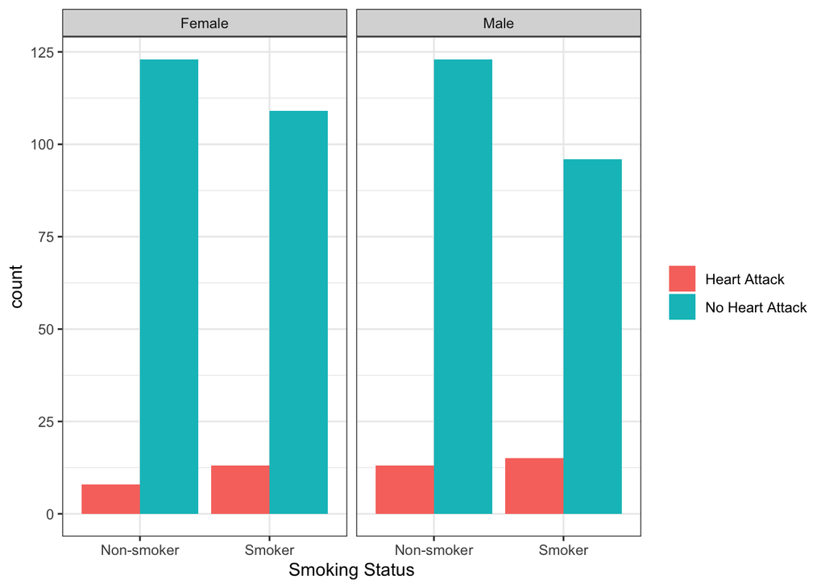

```r
# plotting counts
data %>%
  mutate(sex = ifelse(sex==0, "Male","Female"),
         smoking = ifelse(smoking==0, "Non-smoker","Smoker"),
         outcome = ifelse(outcome==1, "Heart Attack", "No Heart Attack")) %>%
  ggplot(aes(x = smoking, fill = outcome)) +
  geom_bar(position = "dodge") +
  theme_bw() +
  facet_wrap(.~ sex) +
  labs(x = "Smoking Status", fill = element_blank())
```

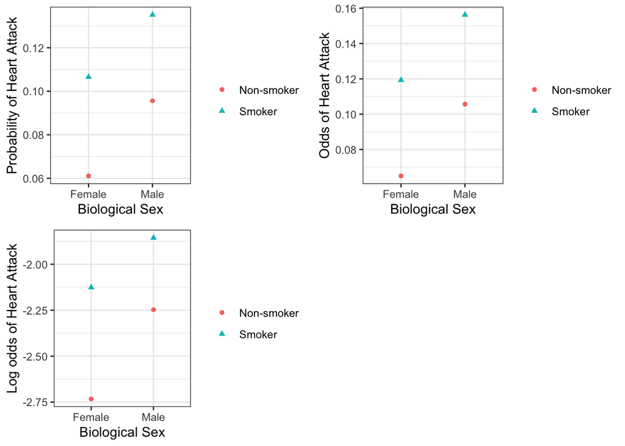

```r
# saving data frame with odds and log odds etc for plotting
summarydf = data %>%
  mutate(sex = ifelse(sex==0, "Male","Female"),
         smoking = ifelse(smoking==0, "Non-smoker","Smoker"))%>%
  group_by(sex, smoking) %>%
  summarise(event = sum(outcome)/n(), no_event = sum(1-outcome)/n()) %>%
  mutate(odds_event = event/no_event,
         log_odds = log(odds_event)) %>% ungroup()

# plotting probabilities
p1 = summarydf %>%
  ggplot(aes(x = sex, y = event, color = smoking, shape = smoking)) +
  geom_point() +
  theme_bw() +
  labs(x = "Biological Sex", y = "Probability of Heart Attack",color = element_blank(),
       shape = element_blank())

# plotting odds
p2 = summarydf %>%
  ggplot(aes(x = sex, y = odds_event, color = smoking, shape = smoking)) +
  geom_point() +
  theme_bw() +
  labs(x = "Biological Sex", y = "Odds of Heart Attack",color = element_blank(),
       shape = element_blank())

# plotting log odds
p3 = summarydf %>%
  ggplot(aes(x = sex, y = log_odds, color = smoking, shape = smoking)) +
  geom_point() +
  theme_bw() +
  labs(x = "Biological Sex", y = "Log odds of Heart Attack",color = element_blank(),
       shape = element_blank())

# this lets us put all of those plots next to each other
gridExtra::grid.arrange(p1, p2, p3, nrow = 2)
```

Here we can see the the group with the highest odds ( and log odds and probability) of the event is male smokers, followed by female smokers, then by male non-smokers, and finally, female non-smokers have the lowest odds of the event.

## Odds and odds ratios

What is the odds ratio the event comparing smokers to non smokers within both biological sexes?

```r
# calculate odds ratios
kable(summarydf %>% group_by(sex) %>% mutate(odds_ratio = odds_event[2]/odds_event[1])) %>%
  kable_styling(bootstrap_options = "striped")
```

| sex | smoking | event | no_event | odds_event | log_odds | odds_ratio |
| --- | --- | --- | --- | --- | --- | --- |
| Female | Non-smoker | 0.0610687 | 0.9389313 | 0.0650407 | -2.732743 | 1.833716 |
| Female | Smoker | 0.1065574 | 0.8934426 | 0.1192661 | -2.126399 | 1.833716 |
| Male | Non-smoker | 0.0955882 | 0.9044118 | 0.1056911 | -2.247235 | 1.478365 |
| Male | Smoker | 0.1351351 | 0.8648649 | 0.1562500 | -1.856298 | 1.478365 |

```r
# alternatively
# odds for female smokers
odds_female_smoker = (13/122)/(109/122)
# odds for female non-smokers
odds_female_nonsmoker = (8/131)/(123/131)
# female smokers vs nonsmokers
or_female = odds_female_smoker/odds_female_nonsmoker



# odds for male smokers
odds_male_smoker = (15/111)/(96/111)
# odds for male non-smokers
odds_male_nonsmoker = (13/136)/(123/136)
# male smokers vs nonsmokers
or_male = odds_male_smoker/odds_male_nonsmoker

# print them with labels for readability (rounding to 2 digits)
paste0("Odds for female smokers: ", round(odds_female_smoker,2) )
```

```
## [1] "Odds for female smokers: 0.12"
```

```r
paste0("Odds for female smokers: ", round(odds_female_nonsmoker,2) )
```

```
## [1] "Odds for female smokers: 0.07"
```

```r
paste0("Odds for male smokers: ", round(odds_male_smoker,2) )
```

```
## [1] "Odds for male smokers: 0.16"
```

```r
paste0("Odds for male smokers: ", round(odds_male_nonsmoker,2) )
```

```
## [1] "Odds for male smokers: 0.11"
```

```r
paste0("Odds ratio (female smoker) vs (female non-smoker): ", round(or_female,2) )
```

```
## [1] "Odds ratio (female smoker) vs (female non-smoker): 1.83"
```

```r
paste0("Odds ratio (male smoker) vs (male non-smoker): ", round(or_male,2) )
```

```
## [1] "Odds ratio (male smoker) vs (male non-smoker): 1.48"
```

Here we can see that among the female group, the odds of heart attack are 83% higher (ratio is 1.83) among smokers compared to non-smokers. For the male group, this difference isn’t quite as large. In the male group, the odds of heart attack are about 48% higher for smokers compared to non-smokers (this ratio is 1.48).

Wait, but didn’t we say that the group with the highest odds of heart attack were the male smokers? How does that work?

Remember that odds ratios are **ratios**, meaning the association they’re modeling is multiplicative.

$$\frac{\text{odds}_\text{smoker &
female}}{\text{odds}_\text{non-smoker & female}} = 1.83 \implies
\text{odds}_\text{smoker & female} =
1.83\times\text{odds}_\text{non-smoker & female}$$

$$\frac{\text{odds}_\text{smoker &
male}}{\text{odds}_\text{non-smoker & male}} = 1.48 \implies
\text{odds}_\text{smoker & male} =
1.48\times\text{odds}_\text{non-smoker & male}$$

So even though the ratio is larger for the female group (comparing smokers to non-smokers), that doesn’t mean the odds themselves are higher, because this depends on what the odds are in the baseline categories (male and female non-smokers).

## Log odds and log odds ratios

We can also take the log of all of these quantities (to compare to our logistic regression model later on). Remember that the log odds ratio can also be interpreted as the difference in log odds

$$log(1.83) =
log\left(\frac{\text{odds}_\text{smoker &
female}}{\text{odds}_\text{non-smoker & female}}\right) =
log(\text{odds}_\text{smoker &
female})-log(\text{odds}_\text{non-smoker & female})$$
and

$$log(1.48) =
log\left(\frac{\text{odds}_\text{smoker &
male}}{\text{odds}_\text{non-smoker & male}}\right) =
log(\text{odds}_\text{smoker &
male})-log(\text{odds}_\text{non-smoker & male})$$

```r
# print log odds and log odds ratios

paste0("Log odds female smoker: ", log(odds_female_smoker))
```

```
## [1] "Log odds female smoker: -2.12639852476761"
```

```r
paste0("Log odds female non-smoker: ", log(odds_female_nonsmoker))
```

```
## [1] "Log odds female non-smoker: -2.73274281369258"
```

```r
paste0("Log odds ratio for females: ", log(or_female))
```

```
## [1] "Log odds ratio for females: 0.606344288924975"
```

```r
paste0("Log odds male smoker: ", log(odds_male_smoker))
```

```
## [1] "Log odds male smoker: -1.85629799036563"
```

```r
paste0("Log odds male non-smoker: ", log(odds_male_nonsmoker))
```

```
## [1] "Log odds male non-smoker: -2.24723499791088"
```

```r
paste0("Log odds ratio for males: ", log(or_male))
```

```
## [1] "Log odds ratio for males: 0.390937007545255"
```

## Ratio of odds ratios

How much bigger is the female-specific odds ratio (comparing smokers to non-smokers) than the male-specific odds ratio?

```r
# print ratio of odds ratios
paste0("Ratio of odds ratios (female vs male): ",or_female/or_male)
```

```
## [1] "Ratio of odds ratios (female vs male): 1.24036697247706"
```

Since this is bigger than one, the female-specific odds ratio is larger. Specifically, the female-specific odds ratio is 24% larger than (1.24 times) the male-specific odds ratio.

On the log-scale this is:

```r
# print the log ratio of odds ratios
paste0("Log of Ratio of odds ratios (female vs male): ",log(or_female/or_male))
```

```
## [1] "Log of Ratio of odds ratios (female vs male): 0.21540728137972"
```

This can either be interpreted as the log of the ratio of the odds ratios

$$log\left(\frac{\frac{\text{odds}_\text{smoker
& female}}{\text{odds}_\text{non-smoker &
female}}}{\frac{\text{odds}_\text{smoker &
male}}{\text{odds}_\text{non-smoker & male}}}\right)$$
But can also be interpreted as the difference in log odds ratios (or difference in differences in log odds):

$$=log\left(\frac{\text{odds}_\text{smoker
& female}}{\text{odds}_\text{non-smoker &
female}}\right)-log\left(\frac{\text{odds}_\text{smoker &
male}}{\text{odds}_\text{non-smoker & male}}\right)$$
Here we get a positive number, indicating that that the female-specific log odds ratio is **bigger** than the male-specific log odds ratio. The difference in log-odds between smokers and non-smokers is larger among female patients than it is among male patients.

# Logistic Regression

Now let’s fit a logistic regression model with sex, smoking status, and an interaction between the two.

$$log(\text{odds heart attack})=\beta_0 +
\beta_1 I(\text{female}) + \beta_2 I(\text{smoker}) + \beta_3
\left(I(\text{female})\times I(\text{smoker}) \right)$$

```r
# logistic regression model with interaction term
model <- glm(outcome ~ sex + smoking + interaction, data = data, family = binomial(link = "logit"))

# model output
summary(model)
```

```
##
## Call:
## glm(formula = outcome ~ sex + smoking + interaction, family = binomial(link = "logit"),
##     data = data)
##
## Coefficients:
##             Estimate Std. Error z value Pr(>|z|)
## (Intercept)  -2.2472     0.2916  -7.706  1.3e-14 ***
## sex          -0.4855     0.4671  -1.039    0.299
## smoking       0.3909     0.4027   0.971    0.332
## interaction   0.2154     0.6175   0.349    0.727
## ---
## Signif. codes:  0 '***' 0.001 '**' 0.01 '*' 0.05 '.' 0.1 ' ' 1
##
## (Dispersion parameter for binomial family taken to be 1)
##
##     Null deviance: 320.67  on 499  degrees of freedom
## Residual deviance: 316.69  on 496  degrees of freedom
## AIC: 324.69
##
## Number of Fisher Scoring iterations: 5
```

Some of these numbers should look familiar!

## Log odds

Let’s write out the model by biological sex:

- Male non-smokers:

$$log(\text{odds heart attack})=\beta_0 =
-2.247$$

- Male smokers:

$$log(\text{odds heart attack})=\beta_0 +
\beta_2 = -2.247 + 0.391 = -1.856$$

- Female non-smokers:

$$log(\text{odds heart attack})=\beta_0 =
-2.247 - 0.4855 = -2.733$$

- Female smokers:

$$log(\text{odds heart attack})=\beta_0 +
\beta_2 = -2.247 - 0.4855 + 0.391 + 0.215 = -2.126$$

## Odds

Exponentiating we get:

```r
# save coefficient values
b0 = model$coefficients[1] ; b1 = model$coefficients[2] ; b2 = model$coefficients[3] ; b3 = model$coefficients[4] ;

# print out odds from model

paste0("Odds male nonsmokers: ", exp(b0 ))
```

```
## [1] "Odds male nonsmokers: 0.105691056910569"
```

```r
paste0("Odds male smokers: ", exp(b0 + b2))
```

```
## [1] "Odds male smokers: 0.15625"
```

```r
paste0("Odds female nonsmokers: ", exp(b0 + b1))
```

```
## [1] "Odds female nonsmokers: 0.0650406504167456"
```

```r
paste0("Odds female nonsmokers: ", exp(b0 + b1 + b2 + b3))
```

```
## [1] "Odds female nonsmokers: 0.119266055045872"
```

## Odds ratios and log odds ratios

What about the log odds ratios?

For males this is:

$$log\left(\frac{\text{odds}_\text{male,smoker}}{\text{odds}_\text{male,non-smoker}}\right)=log(\text{odds}_\text{male,smoker})-log(\text{odds}_\text{male,smoker})\\=
(\beta_0+\beta_2)-\beta_0\\=\beta_2$$

For females this is:

$$log\left(\frac{\text{odds}_\text{female,smoker}}{\text{odds}_\text{female,non-smoker}}\right)=log(\text{odds}_\text{female,smoker})-log(\text{odds}_\text{female,smoker})\\=
(\beta_0+\beta_1+\beta_2+\beta_3)-(\beta_0+\beta_1)\\=\beta_2+\beta_3$$

And if we wanted the odds ratios? Exponentiate!

$$OR_{\text{male}} = e^{\beta_2} \text{
and } OR_{\text{female}} = e^{\beta_2+\beta_3}$$

```r
# print out log odds ratios and odds ratios

paste0("Log odds ratio male: ", b2)
```

```
## [1] "Log odds ratio male: 0.390937007545255"
```

```r
paste0("Log odds ratio female: ", b2 + b3)
```

```
## [1] "Log odds ratio female: 0.606344288767511"
```

```r
paste0("Odds ratio male: ", exp(b2))
```

```
## [1] "Odds ratio male: 1.47836538461539"
```

```r
paste0("Odds ratio female: ", exp(b2 + b3))
```

```
## [1] "Odds ratio female: 1.83371559604153"
```

## Ratio of odds ratios

So then what is $\beta_3$? It’s the log odds ratio for females (comparing smokers to non-smokers) minus the log odds ratio for males (comparing smokers to non-smokers). This is also the same as the log of the ratio of the odds ratios. If we exponentiate, it should give us that 1.24 ratio we calculated from the table above.

```r
# ratio of odds ratios and log of that ratio
paste0("Log(odds ratio female) - Log(odds ratio male): ", b3)
```

```
## [1] "Log(odds ratio female) - Log(odds ratio male): 0.215407281222256"
```

```r
paste0("odds ratio female/odds ratio male: ", exp(b3))
```

```
## [1] "odds ratio female/odds ratio male: 1.24036697228175"
```

That’s exactly what we got before!

$$e^{\beta_3}=\frac{1.834}{1.478}=1.24$$
$$\beta_3 =
log(e^{\beta_3})=log\left(\frac{1.834}{1.478}\right)=log(1.834)-log(1.478)=0.215$$

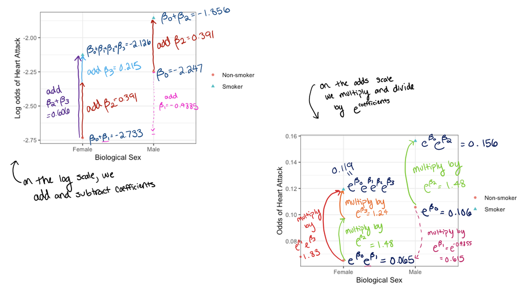

# Continuous predictors

If we had continuous predictors instead of catgeorical, we would interpret the coefficients the same way, just instead of the log odds comparing one group to the reference group, we would be looking at the difference after a one-unit increase in the continuous predictor. For example, if age and BMI are our two continuous variables, the interaction term for age and BMI would be:

$$log\left(\frac{\text{odds}_{\text{age} = \color{blue}{a + 1} \&
\text{BMI} = \color{purple}{b + 1} }}{\text{odds}_{\text{age} =
\color{blue}{a} \& \text{BMI} = \color{purple}{b + 1}
}}\right)-log\left(\frac{\text{odds}_{\text{age} = \color{blue}{a + 1}
\& \text{BMI} = \color{purple}{b} }}{\text{odds}_{\text{age} =
\color{blue}{a} \& \text{BMI} = \color{purple}{b } }}\right)$$

or equivalently,

$$log\left(\frac{\text{odds}_{\text{age} = \color{blue}{a + 1} \&
\text{BMI} = \color{purple}{b + 1} }}{\text{odds}_{\text{age} =
\color{blue}{a+1} \& \text{BMI} = \color{purple}{b }
}}\right)-log\left(\frac{\text{odds}_{\text{age} = \color{blue}{a}
\& \text{BMI} = \color{purple}{b+1} }}{\text{odds}_{\text{age} =
\color{blue}{a} \& \text{BMI} = \color{purple}{b} }}\right)$$
That is, how much the log odds ratio for age (the log OR associated with increasing age by 1) changes as BMI increases by 1 or, equivalently, how much the log odds ratio for BMI (the log OR associated with increasing BMI by 1) changes as age increases by 1. Basically, the difference in the slope for age when BMI changes, or the difference in the slope for BMI when age changes (it’s just that in logistic regression the special word for “slope” is “log odds ratio”).